# Netwok Analysis Project

We can take a general look at the results using the layouts that are based on maximizing energy functions:

[figure not shown]

```r
par(mfrow=c(1,2))
#Davidson-Harel layout
plot.net(network, layout = layout_with_dh, cex = 0.5)
#Fruchtermann and Reingold layout
plot.net(network, layout = layout_with_fr, cex = 0.5)
```

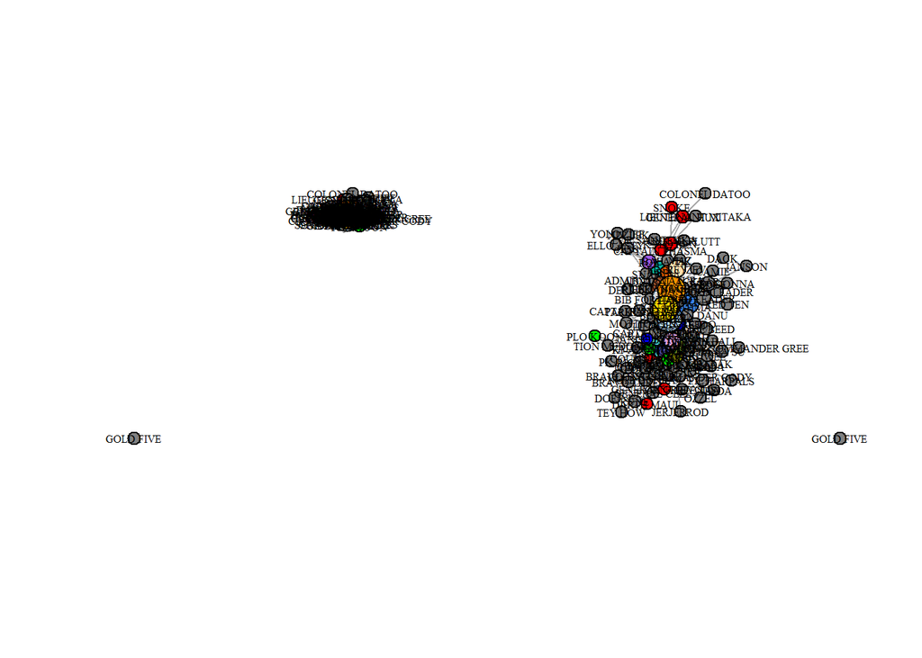

```r
par(mfrow=c(1,2))
#GEM force-directed layout
plot.net(network, layout = layout_with_gem, cex = 0.5)
#Graphopt layout
plot.net(network, layout = layout_with_graphopt, cex = 0.5)
```

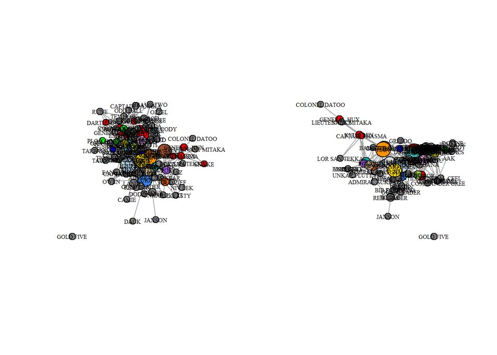

```r
par(mfrow=c(1,2))
#Kamada and Kawai layout
plot.net(network, layout = layout_with_kk, cex = 0.5)
#Multidimensional Scaling layout
plot.net(network, layout = layout_with_mds, cex = 0.5)
```

The results are not very good, and they are more or less the same, with the exception of GEM force-directed layout, which is much worse.

A layout that will allow us to better see the vertex even if we loose some visualization of the edges is the grid layout:

[figure not shown]

```r
plot.net(network, layout = layout_on_grid, cex = 0.25)
```

To better visualize the edges, we can use a chord diagram. It allows us to see the edges very clearly and also highlights those nodes that have a higher importance giving them more space in the outer circle.

```r
adj_matrix <- as_adjacency_matrix(network,attr = "weight",sparse = T)
chorddiag(as.matrix(adj_matrix),showTicks = FALSE, margin = 40, groupnameFontsize = 4)
```

[interactive chart not shown]